# RR project: Best Books By Century

Marian Nehrebecki, Aleksander Partyga, Magdalena Sobala

26 May, 2022

# Best Books By Century summary in numbers

### Overview

(From the [Goodreads](https://www.goodreads.com)) Goodreads is the world’s largest site for readers and book recommendations. The mission of Goodreads is to help people find and share books they love. Goodreads launched in January 2007.

### A Few Things We Can Do On Goodreads

> - See what books our friends are reading.
> - Track the books we’ re reading, have read, and want to read.
> - Check out our personalized book recommendations. The recommendation engine analyzes 20 billion data points to give suggestions tailored to our literary tastes.
> - Find out if a book is a good fit for us from our community’s reviews.

### Centries 4 summary

The above literature items can be found on the website:

> “https://www.goodreads.com/book/show/27037.Confessions”.

### Initial Analysis:

#### Score points of the books by century 4

It should be noted how the **scoring** changes for books by **century 4** in Figure 1.

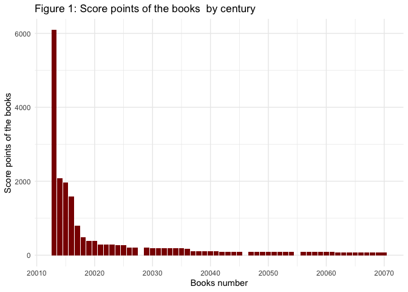

**Comments:**

- The maximum score points of the books by *century 4* are equal 6089 for the book: **Confessions**.
- The average score points of the books by *century 4* are equal 363.2.
- The minimum score points of the books by *century 4* are equal 72 for the book: **The Military Institutions of the Romans**.

#### Votes of the books by century 4

It should be noted how the **votes** changes for books by **century 4** in Figure 2.

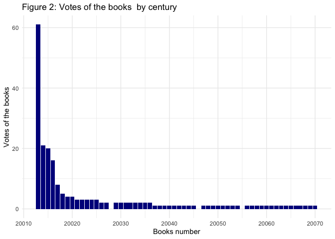

**Comments:**

- The maximum votes of the books by *century 4* are equal 61 for the book: **Confessions**.
- The average votes of the books by *century 4* are equal 3.7.
- The minimum votes of the books by *century 4* are equal 1.

#### Average rating of the books by century 4

It should be noted how the **average rating** changes for books by **century 4** in Figure 3.

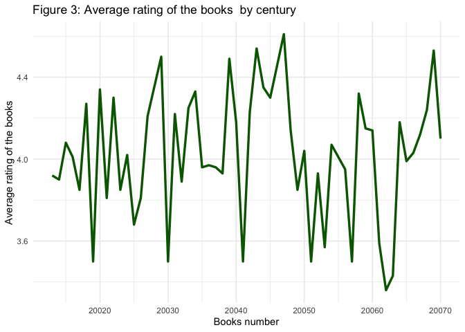

**Comments:**

- The maximum average rating of the books by *century 4* are equal 4.6 for the book: **Biblia Sacra Vulgata**.
- The average rating of the books by *century 4* are equal 4.
- The minimum average rating of the books by *century 4* are equal 3.4 for the book: **Dionysiaca, Books 16-35 (Loeb Classical Library, #354)**.

Finally, the books with the above-average rating (see Table 1):

**Table 1.** The books with the above average rating

| Century | Title | Author | website |
| --- | --- | --- | --- |
| 4th | The Later Roman Empire (A.D. 354-378) | Ammianus Marcellinus | https://www.goodreads.com/book/show/669343.The_Later_Roman_Empire |
| 4th | On the Incarnation | Athanasius of Alexandria | https://www.goodreads.com/book/show/673655.On_the_Incarnation |
| 4th | The Trinity | Augustine of Hippo | https://www.goodreads.com/book/show/785972.The_Trinity |
| 4th | Works on the Spirit | Athanasius of Alexandria | https://www.goodreads.com/book/show/13496664-works-on-the-spirit |
| 4th | The Fall of Troy | Quintus Smyrnaeus | https://www.goodreads.com/book/show/1291673.The_Fall_of_Troy |
| 4th | The Nag Hammadi Library | Unknown Nag Hammadi | https://www.goodreads.com/book/show/743049.The_Nag_Hammadi_Library |
| 4th | On the Deaths of the Persecutors: A Translation of De Mortibus Persecutorum by Lucius Caecilius Firmianus Lactantius | Firmianus Lactantius | https://www.goodreads.com/book/show/58082600-on-the-deaths-of-the-persecutors |
| 4th | The Life of Moses | Gregory of Nyssa | https://www.goodreads.com/book/show/102122.The_Life_of_Moses |
| 4th | The Life Of St. Anthony | Athanasius of Alexandria | https://www.goodreads.com/book/show/349271.The_Life_Of_St_Anthony |
| 4th | Letter to Marcellinus on the Psalms: Spiritual Wisdom for Today | Athanasius of Alexandria | https://www.goodreads.com/book/show/35237693-letter-to-marcellinus-on-the-psalms |
| 4th | Hymns on Paradise | Ephrem the Syrian | https://www.goodreads.com/book/show/555083.Hymns_on_Paradise |
| 4th | Kumarasambhavam: The Origin of the Young God | Kālidāsa | https://www.goodreads.com/book/show/30059502-kumarasambhavam |
| 4th | The Meghadūta of Kālidāsa | Kālidāsa | https://www.goodreads.com/book/show/896422.The_Meghad_ta_of_K_lid_sa |
| 4th | Greek New Testament | Anonymous | https://www.goodreads.com/book/show/686183.Greek_New_Testament |
| 4th | Raghuvamsam: The Line of Raghu | Kālidāsa | https://www.goodreads.com/book/show/30123682-raghuvamsam |
| 4th | The Five Theological Orations | Gregory of Nazianzus | https://www.goodreads.com/book/show/7673001-the-five-theological-orations |
| 4th | Biblia Sacra Vulgata | Anonymous | https://www.goodreads.com/book/show/775634.Biblia_Sacra_Vulgata |
| 4th | Against The Heathen | Athanasius of Alexandria | https://www.goodreads.com/book/show/9990144-against-the-heathen |
| 4th | On Christian Teaching | Augustine of Hippo | https://www.goodreads.com/book/show/3182208-on-christian-teaching |
| 4th | Of True Religion | Augustine of Hippo | https://www.goodreads.com/book/show/9884186-of-true-religion |
| 4th | The Catechetical Lectures of St. Cyril of Jerusalem | Cyril of Jerusalem | https://www.goodreads.com/book/show/19034180-the-catechetical-lectures-of-st-cyril-of-jerusalem |
| 4th | The Book of Lieh-Tzŭ: A Classic of Tao | Liezi | https://www.goodreads.com/book/show/448840.The_Book_of_Lieh_Tz_ |
| 4th | The Saturnalia | Macrobius | https://www.goodreads.com/book/show/19003647-the-saturnalia |
| 4th | On the Soul and Resurrection | Gregory of Nyssa | https://www.goodreads.com/book/show/555076.On_the_Soul_and_Resurrection |
| 4th | On the Making of Man | Gregory of Nyssa | https://www.goodreads.com/book/show/18831740-on-the-making-of-man |
| 4th | On the Holy Spirit | Gregory of Nyssa | https://www.goodreads.com/book/show/24575294-on-the-holy-spirit |
| 4th | The Yoga Sutras of Patanjali | Patañjali | https://www.goodreads.com/book/show/560946.The_Yoga_Sutras_of_Patanjali |
| 4th | The Hymns on Faith | Ephrem the Syrian | https://www.goodreads.com/book/show/24826391-the-hymns-on-faith |
| 4th | The Military Institutions of the Romans | Vegetius | https://www.goodreads.com/book/show/1374990.The_Military_Institutions_of_the_Romans |

**Comments:**

- The total number of the books by *century 4* are equal: **55**.
- The number of books with the above average rating by *century 4* are equal: **29**.

### References:

https://www.goodreads.com